# Risk Factor Analysis

## Outcome Variable

**Outcome Variable:** haz

## Predictor Variables

**Intervention Variable:** cleanck

**Adjustment Set:**

- arm
- sex
- W_mage
- meducyrs
- feducyrs
- hhwealth_quart
- W_nrooms
- W_nhh
- W_nchldlt5
- trth2o
- impfloor
- delta_meducyrs
- delta_feducyrs
- delta_hhwealth_quart
- delta_W_nrooms
- delta_W_nhh
- delta_W_nchldlt5
- delta_trth2o
- delta_impfloor

## Stratifying Variables

The analysis was stratified on these variable(s):

- agecat
- studyid
- country

## Data Summary

| agecat | studyid | country | cleanck | n_cell | n |
| --- | --- | --- | --- | --- | --- |
| Birth | ki0047075b-MAL-ED | PERU | 1 | 1 | 2 |
| Birth | ki0047075b-MAL-ED | PERU | 0 | 1 | 2 |
| Birth | ki1000108-CMC-V-BCS-2002 | INDIA | 1 | 39 | 92 |
| Birth | ki1000108-CMC-V-BCS-2002 | INDIA | 0 | 53 | 92 |
| Birth | ki1000108-IRC | INDIA | 1 | 218 | 378 |
| Birth | ki1000108-IRC | INDIA | 0 | 160 | 378 |
| Birth | ki1017093b-PROVIDE | BANGLADESH | 1 | 438 | 539 |
| Birth | ki1017093b-PROVIDE | BANGLADESH | 0 | 101 | 539 |
| Birth | ki1017093c-NIH-Crypto | BANGLADESH | 1 | 345 | 561 |
| Birth | ki1017093c-NIH-Crypto | BANGLADESH | 0 | 216 | 561 |
| Birth | ki1113344-GMS-Nepal | NEPAL | 1 | 9 | 621 |
| Birth | ki1113344-GMS-Nepal | NEPAL | 0 | 612 | 621 |
| 6 months | ki0047075b-MAL-ED | SOUTH AFRICA | 1 | 1 | 1 |
| 6 months | ki0047075b-MAL-ED | SOUTH AFRICA | 0 | 0 | 1 |
| 6 months | ki1000108-CMC-V-BCS-2002 | INDIA | 1 | 163 | 369 |
| 6 months | ki1000108-CMC-V-BCS-2002 | INDIA | 0 | 206 | 369 |
| 6 months | ki1000108-IRC | INDIA | 1 | 230 | 398 |
| 6 months | ki1000108-IRC | INDIA | 0 | 168 | 398 |
| 6 months | ki1017093b-PROVIDE | BANGLADESH | 1 | 498 | 604 |
| 6 months | ki1017093b-PROVIDE | BANGLADESH | 0 | 106 | 604 |
| 6 months | ki1017093c-NIH-Crypto | BANGLADESH | 1 | 329 | 545 |
| 6 months | ki1017093c-NIH-Crypto | BANGLADESH | 0 | 216 | 545 |
| 6 months | ki1113344-GMS-Nepal | NEPAL | 1 | 8 | 505 |
| 6 months | ki1113344-GMS-Nepal | NEPAL | 0 | 497 | 505 |
| 24 months | ki0047075b-MAL-ED | SOUTH AFRICA | 1 | 1 | 1 |
| 24 months | ki0047075b-MAL-ED | SOUTH AFRICA | 0 | 0 | 1 |
| 24 months | ki1000108-CMC-V-BCS-2002 | INDIA | 1 | 163 | 371 |
| 24 months | ki1000108-CMC-V-BCS-2002 | INDIA | 0 | 208 | 371 |
| 24 months | ki1000108-IRC | INDIA | 1 | 231 | 400 |
| 24 months | ki1000108-IRC | INDIA | 0 | 169 | 400 |
| 24 months | ki1017093b-PROVIDE | BANGLADESH | 1 | 479 | 578 |
| 24 months | ki1017093b-PROVIDE | BANGLADESH | 0 | 99 | 578 |
| 24 months | ki1017093c-NIH-Crypto | BANGLADESH | 1 | 199 | 410 |
| 24 months | ki1017093c-NIH-Crypto | BANGLADESH | 0 | 211 | 410 |
| 24 months | ki1113344-GMS-Nepal | NEPAL | 1 | 5 | 435 |
| 24 months | ki1113344-GMS-Nepal | NEPAL | 0 | 430 | 435 |

The following strata were considered:

- agecat: 24 months, studyid: ki0047075b-MAL-ED, country: SOUTH AFRICA
- agecat: 24 months, studyid: ki1000108-CMC-V-BCS-2002, country: INDIA
- agecat: 24 months, studyid: ki1000108-IRC, country: INDIA
- agecat: 24 months, studyid: ki1017093b-PROVIDE, country: BANGLADESH
- agecat: 24 months, studyid: ki1017093c-NIH-Crypto, country: BANGLADESH
- agecat: 24 months, studyid: ki1113344-GMS-Nepal, country: NEPAL
- agecat: 6 months, studyid: ki0047075b-MAL-ED, country: SOUTH AFRICA
- agecat: 6 months, studyid: ki1000108-CMC-V-BCS-2002, country: INDIA
- agecat: 6 months, studyid: ki1000108-IRC, country: INDIA
- agecat: 6 months, studyid: ki1017093b-PROVIDE, country: BANGLADESH
- agecat: 6 months, studyid: ki1017093c-NIH-Crypto, country: BANGLADESH
- agecat: 6 months, studyid: ki1113344-GMS-Nepal, country: NEPAL
- agecat: Birth, studyid: ki0047075b-MAL-ED, country: PERU
- agecat: Birth, studyid: ki1000108-CMC-V-BCS-2002, country: INDIA
- agecat: Birth, studyid: ki1000108-IRC, country: INDIA
- agecat: Birth, studyid: ki1017093b-PROVIDE, country: BANGLADESH
- agecat: Birth, studyid: ki1017093c-NIH-Crypto, country: BANGLADESH
- agecat: Birth, studyid: ki1113344-GMS-Nepal, country: NEPAL

### Dropped Strata

Some strata were dropped due to rare outcomes:

- agecat: Birth, studyid: ki0047075b-MAL-ED, country: PERU
- agecat: 6 months, studyid: ki0047075b-MAL-ED, country: SOUTH AFRICA
- agecat: 24 months, studyid: ki0047075b-MAL-ED, country: SOUTH AFRICA

## Methods Detail

We’re interested in the causal parameters $E[Y_a]$ for all values of $a \in \mathcal{A}$. These parameters represent the mean outcome if, possibly contrary to fact, we intervened to set all units to have $A=a$. Under the randomization and positivity assumptions, these are identified by the statistical parameters $\psi_a=E_W[E_{Y|A,W}(Y|A=a,W)]$. In addition, we’re interested in the mean of $Y$, $E[Y]$ under no intervention (the observed mean). We will estimate these parameters by using SuperLearner to fit the relevant likelihood factors – $E_{Y|A,W}(Y|A=a,W)$ and $p(A=a|W)$, and then updating our likelihood fit using a joint TMLE.

For unadjusted analyses ($W=\{\}$), initial likelihoods were estimated using Lrnr_glm to estimate the simple $E(Y|A)$ and Lrnr_mean to estimate $p(A)$. For adjusted analyses, a small library containing Lrnr_glmnet, Lrnr_xgboost, and Lrnr_mean was used.

Having estimated these parameters, we will then use the delta method to estimate relative risks and attributable risks relative to a prespecified baseline level of $A$.

# Results Detail

## Results Plots

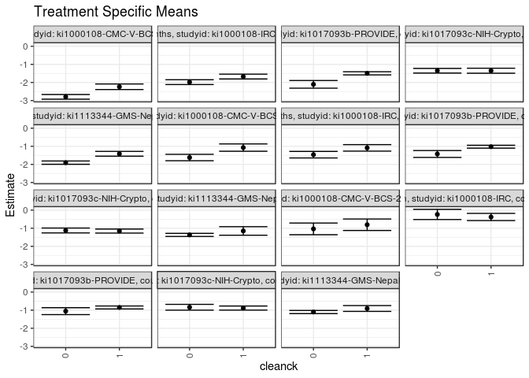

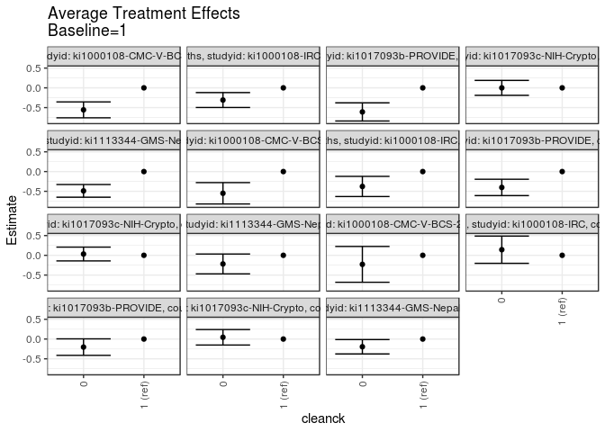

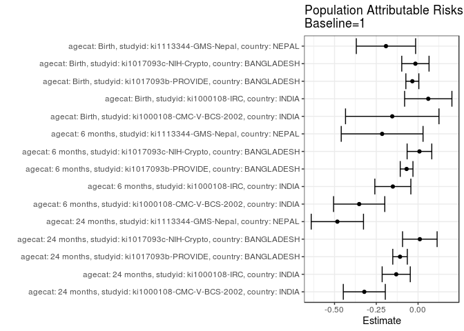

## Results Table

### Parameter: TSM

| agecat | studyid | country | intervention_level | baseline_level | estimate | ci_lower | ci_upper |
| --- | --- | --- | --- | --- | --- | --- | --- |
| Birth | ki1000108-CMC-V-BCS-2002 | INDIA | 1 | NA | -0.8066793 | -1.1240190 | -0.4893397 |
| Birth | ki1000108-CMC-V-BCS-2002 | INDIA | 0 | NA | -1.0358949 | -1.3589264 | -0.7128634 |
| Birth | ki1000108-IRC | INDIA | 1 | NA | -0.3787520 | -0.5776676 | -0.1798364 |
| Birth | ki1000108-IRC | INDIA | 0 | NA | -0.2367168 | -0.5191645 | 0.0457310 |
| Birth | ki1017093b-PROVIDE | BANGLADESH | 1 | NA | -0.8509691 | -0.9329678 | -0.7689703 |
| Birth | ki1017093b-PROVIDE | BANGLADESH | 0 | NA | -1.0546272 | -1.2451640 | -0.8640904 |
| Birth | ki1017093c-NIH-Crypto | BANGLADESH | 1 | NA | -0.8836931 | -0.9966376 | -0.7707486 |
| Birth | ki1017093c-NIH-Crypto | BANGLADESH | 0 | NA | -0.8390248 | -0.9991266 | -0.6789230 |
| Birth | ki1113344-GMS-Nepal | NEPAL | 1 | NA | -0.9077778 | -1.0681024 | -0.7474531 |
| Birth | ki1113344-GMS-Nepal | NEPAL | 0 | NA | -1.1026961 | -1.1887883 | -1.0166039 |
| 6 months | ki1000108-CMC-V-BCS-2002 | INDIA | 1 | NA | -1.0710196 | -1.2737348 | -0.8683044 |
| 6 months | ki1000108-CMC-V-BCS-2002 | INDIA | 0 | NA | -1.6206377 | -1.7982211 | -1.4430544 |
| 6 months | ki1000108-IRC | INDIA | 1 | NA | -1.0864542 | -1.2670049 | -0.9059034 |
| 6 months | ki1000108-IRC | INDIA | 0 | NA | -1.4631582 | -1.6434335 | -1.2828829 |
| 6 months | ki1017093b-PROVIDE | BANGLADESH | 1 | NA | -1.0230774 | -1.1028211 | -0.9433336 |
| 6 months | ki1017093b-PROVIDE | BANGLADESH | 0 | NA | -1.4245029 | -1.6146270 | -1.2343789 |
| 6 months | ki1017093c-NIH-Crypto | BANGLADESH | 1 | NA | -1.1565643 | -1.2677319 | -1.0453966 |
| 6 months | ki1017093c-NIH-Crypto | BANGLADESH | 0 | NA | -1.1239092 | -1.2589492 | -0.9888691 |
| 6 months | ki1113344-GMS-Nepal | NEPAL | 1 | NA | -1.1500000 | -1.3864333 | -0.9135667 |
| 6 months | ki1113344-GMS-Nepal | NEPAL | 0 | NA | -1.3684775 | -1.4530701 | -1.2838850 |
| 24 months | ki1000108-CMC-V-BCS-2002 | INDIA | 1 | NA | -2.2370966 | -2.3906400 | -2.0835533 |
| 24 months | ki1000108-CMC-V-BCS-2002 | INDIA | 0 | NA | -2.7944807 | -2.9237561 | -2.6652052 |
| 24 months | ki1000108-IRC | INDIA | 1 | NA | -1.6732321 | -1.8062436 | -1.5402205 |
| 24 months | ki1000108-IRC | INDIA | 0 | NA | -1.9820585 | -2.1153023 | -1.8488148 |
| 24 months | ki1017093b-PROVIDE | BANGLADESH | 1 | NA | -1.4945980 | -1.5820542 | -1.4071417 |
| 24 months | ki1017093b-PROVIDE | BANGLADESH | 0 | NA | -2.1042687 | -2.3165559 | -1.8919815 |
| 24 months | ki1017093c-NIH-Crypto | BANGLADESH | 1 | NA | -1.3514957 | -1.4904282 | -1.2125633 |
| 24 months | ki1017093c-NIH-Crypto | BANGLADESH | 0 | NA | -1.3521737 | -1.4813423 | -1.2230052 |
| 24 months | ki1113344-GMS-Nepal | NEPAL | 1 | NA | -1.4140000 | -1.5461204 | -1.2818796 |
| 24 months | ki1113344-GMS-Nepal | NEPAL | 0 | NA | -1.9026977 | -1.9936549 | -1.8117404 |

### Parameter: E(Y)

| agecat | studyid | country | intervention_level | baseline_level | estimate | ci_lower | ci_upper |
| --- | --- | --- | --- | --- | --- | --- | --- |
| Birth | ki1000108-CMC-V-BCS-2002 | INDIA | NA | NA | -0.9611957 | -1.1776967 | -0.7446946 |
| Birth | ki1000108-IRC | INDIA | NA | NA | -0.3176455 | -0.4788394 | -0.1564516 |
| Birth | ki1017093b-PROVIDE | BANGLADESH | NA | NA | -0.8851020 | -0.9601332 | -0.8100709 |
| Birth | ki1017093c-NIH-Crypto | BANGLADESH | NA | NA | -0.8996078 | -0.9825064 | -0.8167093 |
| Birth | ki1113344-GMS-Nepal | NEPAL | NA | NA | -1.0998712 | -1.1839267 | -1.0158156 |
| 6 months | ki1000108-CMC-V-BCS-2002 | INDIA | NA | NA | -1.4234508 | -1.5645974 | -1.2823042 |
| 6 months | ki1000108-IRC | INDIA | NA | NA | -1.2373869 | -1.3694835 | -1.1052903 |
| 6 months | ki1017093b-PROVIDE | BANGLADESH | NA | NA | -1.0916915 | -1.1661176 | -1.0172654 |
| 6 months | ki1017093c-NIH-Crypto | BANGLADESH | NA | NA | -1.1482385 | -1.2287866 | -1.0676904 |
| 6 months | ki1113344-GMS-Nepal | NEPAL | NA | NA | -1.3650165 | -1.4477401 | -1.2822929 |
| 24 months | ki1000108-CMC-V-BCS-2002 | INDIA | NA | NA | -2.5588679 | -2.6583730 | -2.4593629 |
| 24 months | ki1000108-IRC | INDIA | NA | NA | -1.8039875 | -1.8980579 | -1.7099171 |
| 24 months | ki1017093b-PROVIDE | BANGLADESH | NA | NA | -1.6024221 | -1.6857420 | -1.5191023 |
| 24 months | ki1017093c-NIH-Crypto | BANGLADESH | NA | NA | -1.3408537 | -1.4302211 | -1.2514862 |
| 24 months | ki1113344-GMS-Nepal | NEPAL | NA | NA | -1.8970805 | -1.9859605 | -1.8082004 |

### Parameter: ATE

| agecat | studyid | country | intervention_level | baseline_level | estimate | ci_lower | ci_upper |
| --- | --- | --- | --- | --- | --- | --- | --- |
| Birth | ki1000108-CMC-V-BCS-2002 | INDIA | 1 | 1 | 0.0000000 | 0.0000000 | 0.0000000 |
| Birth | ki1000108-CMC-V-BCS-2002 | INDIA | 0 | 1 | -0.2292156 | -0.6827643 | 0.2243332 |
| Birth | ki1000108-IRC | INDIA | 1 | 1 | 0.0000000 | 0.0000000 | 0.0000000 |
| Birth | ki1000108-IRC | INDIA | 0 | 1 | 0.1420352 | -0.2031265 | 0.4871968 |
| Birth | ki1017093b-PROVIDE | BANGLADESH | 1 | 1 | 0.0000000 | 0.0000000 | 0.0000000 |
| Birth | ki1017093b-PROVIDE | BANGLADESH | 0 | 1 | -0.2036581 | -0.4125456 | 0.0052293 |
| Birth | ki1017093c-NIH-Crypto | BANGLADESH | 1 | 1 | 0.0000000 | 0.0000000 | 0.0000000 |
| Birth | ki1017093c-NIH-Crypto | BANGLADESH | 0 | 1 | 0.0446683 | -0.1515874 | 0.2409239 |
| Birth | ki1113344-GMS-Nepal | NEPAL | 1 | 1 | 0.0000000 | 0.0000000 | 0.0000000 |
| Birth | ki1113344-GMS-Nepal | NEPAL | 0 | 1 | -0.1949183 | -0.3768960 | -0.0129406 |
| 6 months | ki1000108-CMC-V-BCS-2002 | INDIA | 1 | 1 | 0.0000000 | 0.0000000 | 0.0000000 |
| 6 months | ki1000108-CMC-V-BCS-2002 | INDIA | 0 | 1 | -0.5496181 | -0.8197678 | -0.2794685 |
| 6 months | ki1000108-IRC | INDIA | 1 | 1 | 0.0000000 | 0.0000000 | 0.0000000 |
| 6 months | ki1000108-IRC | INDIA | 0 | 1 | -0.3767041 | -0.6320674 | -0.1213408 |
| 6 months | ki1017093b-PROVIDE | BANGLADESH | 1 | 1 | 0.0000000 | 0.0000000 | 0.0000000 |
| 6 months | ki1017093b-PROVIDE | BANGLADESH | 0 | 1 | -0.4014255 | -0.6083378 | -0.1945133 |
| 6 months | ki1017093c-NIH-Crypto | BANGLADESH | 1 | 1 | 0.0000000 | 0.0000000 | 0.0000000 |
| 6 months | ki1017093c-NIH-Crypto | BANGLADESH | 0 | 1 | 0.0326551 | -0.1420622 | 0.2073724 |
| 6 months | ki1113344-GMS-Nepal | NEPAL | 1 | 1 | 0.0000000 | 0.0000000 | 0.0000000 |
| 6 months | ki1113344-GMS-Nepal | NEPAL | 0 | 1 | -0.2184775 | -0.4695882 | 0.0326332 |
| 24 months | ki1000108-CMC-V-BCS-2002 | INDIA | 1 | 1 | 0.0000000 | 0.0000000 | 0.0000000 |
| 24 months | ki1000108-CMC-V-BCS-2002 | INDIA | 0 | 1 | -0.5573840 | -0.7587324 | -0.3560357 |
| 24 months | ki1000108-IRC | INDIA | 1 | 1 | 0.0000000 | 0.0000000 | 0.0000000 |
| 24 months | ki1000108-IRC | INDIA | 0 | 1 | -0.3088264 | -0.4974831 | -0.1201697 |
| 24 months | ki1017093b-PROVIDE | BANGLADESH | 1 | 1 | 0.0000000 | 0.0000000 | 0.0000000 |
| 24 months | ki1017093b-PROVIDE | BANGLADESH | 0 | 1 | -0.6096707 | -0.8393794 | -0.3799621 |
| 24 months | ki1017093c-NIH-Crypto | BANGLADESH | 1 | 1 | 0.0000000 | 0.0000000 | 0.0000000 |
| 24 months | ki1017093c-NIH-Crypto | BANGLADESH | 0 | 1 | -0.0006780 | -0.1899364 | 0.1885804 |
| 24 months | ki1113344-GMS-Nepal | NEPAL | 1 | 1 | 0.0000000 | 0.0000000 | 0.0000000 |
| 24 months | ki1113344-GMS-Nepal | NEPAL | 0 | 1 | -0.4886977 | -0.6491003 | -0.3282950 |

### Parameter: PAR

| agecat | studyid | country | intervention_level | baseline_level | estimate | ci_lower | ci_upper |
| --- | --- | --- | --- | --- | --- | --- | --- |
| Birth | ki1000108-CMC-V-BCS-2002 | INDIA | 1 | NA | -0.1545163 | -0.4342264 | 0.1251937 |
| Birth | ki1000108-IRC | INDIA | 1 | NA | 0.0611065 | -0.0804869 | 0.2026999 |
| Birth | ki1017093b-PROVIDE | BANGLADESH | 1 | NA | -0.0341330 | -0.0729648 | 0.0046988 |
| Birth | ki1017093c-NIH-Crypto | BANGLADESH | 1 | NA | -0.0159148 | -0.0975820 | 0.0657525 |
| Birth | ki1113344-GMS-Nepal | NEPAL | 1 | NA | -0.1920934 | -0.3695311 | -0.0146557 |
| 6 months | ki1000108-CMC-V-BCS-2002 | INDIA | 1 | NA | -0.3524311 | -0.5057251 | -0.1991372 |
| 6 months | ki1000108-IRC | INDIA | 1 | NA | -0.1509328 | -0.2587665 | -0.0430990 |
| 6 months | ki1017093b-PROVIDE | BANGLADESH | 1 | NA | -0.0686141 | -0.1066886 | -0.0305397 |
| 6 months | ki1017093c-NIH-Crypto | BANGLADESH | 1 | NA | 0.0083257 | -0.0654940 | 0.0821454 |
| 6 months | ki1113344-GMS-Nepal | NEPAL | 1 | NA | -0.2150165 | -0.4598610 | 0.0298280 |
| 24 months | ki1000108-CMC-V-BCS-2002 | INDIA | 1 | NA | -0.3217713 | -0.4474982 | -0.1960444 |
| 24 months | ki1000108-IRC | INDIA | 1 | NA | -0.1307554 | -0.2149118 | -0.0465991 |
| 24 months | ki1017093b-PROVIDE | BANGLADESH | 1 | NA | -0.1078242 | -0.1512959 | -0.0643524 |
| 24 months | ki1017093c-NIH-Crypto | BANGLADESH | 1 | NA | 0.0106421 | -0.0927878 | 0.1140719 |
| 24 months | ki1113344-GMS-Nepal | NEPAL | 1 | NA | -0.4830805 | -0.6395498 | -0.3266111 |